# IRT / RTSM User Acceptance Testing

Confirming the build before the first participant is randomized

## What a UAT is

You confirm, in a test environment, that the vendor’s randomization and drug-supply build does **exactly** what your specs say, before a single real participant is randomized.

[figure not shown]

Operations-only, synthetic, no PHI.

## Where it runs: the systems

- **Staging IRT / RTSM** (vendor): the web app you operate in a browser, plus the approved test list.
- **You, the biostatistician:** execute each case, capture dated screenshot evidence, and transcribe results into your workbook.
- **Vendor defect tracker:** log failures; the vendor promotes a fixed build back to staging for retest.
- **eTMF:** the signed sign-off package is filed as the record.

The workbook does not connect to the IRT. You transcribe on purpose, so the record is attributable and stands alone for an auditor.

## Readiness snapshot, computed when built

NOT ready - blocked

✘ **2** critical tests not passing

✘ **2** open critical/major; **0** unretested closed; **0** untracked failures

✘ **1** invalid/missing coverage; **5** unfinished tests

**All groups must clear:** critical tests pass; defect and linked-retest checks clear; valid test references and completed execution. Evidence, coverage completeness, and signed approval still require human review. The workbook has separate automatic and manual checks.

## Snapshot

29

Test scripts

22

Passed

2

Failed

3

Open defects

97%

Traced

Every number here comes from the UAT data files, never from an assistant.

## Execution by area

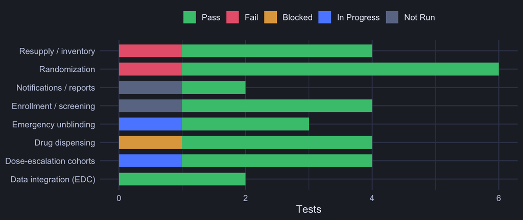

## How to write an executable test

**RAND-02, stratified allocation.** A good test has a specific, verifiable expected result, not “works correctly”.

- **Precondition:** test list loaded; the <70 kg stratum, block 1, has an unused slot.
- **Steps:** register participant 101-001 at 68.0 kg, randomize, record kit + confirmation, open the allocation report as the unblinded statistician.
- **Expected:** allocated to the **next unused <70 kg / block-1 entry**; arm, sequence, and kit match the list; the investigator sees a **kit ID only**, not the arm.
- **Verify:** compare cell-for-cell across every stratum and both arms, not one happy-path participant.

## Severity drives the gate

| Severity | Meaning | Blocks go-live? |
| --- | --- | --- |
| **Critical** | Could break the blind, mis-randomize, mis-dose, or corrupt integrity | **Yes** |
| **Major** | Significant functional error in a key workflow (resupply, wrong kit, missing alert) | **Yes, until fixed** |
| **Minor** | Cosmetic / non-functional (label typo, missing site number) | No; fix or waive with rationale |

One open Critical or Major defect holds the gate. That is the whole point: severity, not count, decides.

## Run it, and build it

The interactive tool is a real R Shiny app you own:

```bash
Rscript launch_app.R uat --install
```

Mark tests, retest fixes, and update traceability to recompute the screen. R logic is shared by the app, these slides, and tests. Adapt and validate all three input files before reuse. CSV export contains tests only: preserve defects, traceability, evidence, and approvals separately.

## Pick your mode

- **Explore / run:** Run & build the Shiny app
- **Share (no R):** the dashboard
- **Skim:** the one-page cheat-sheet
- **Read:** the full guide

*Synthetic data throughout. UAT sign-off is a named-human decision.*